# Reproducible Research: Peer Assessment 1

## Loading and preprocessing the data

Ensure that the required file is present and read data into obect called “activity”

Create a date.TIME column using date and interval

from the date.TIME column, create a new date-independant TIME column for comparison of activity pattern across days

## What is mean total number of steps taken per day?

Determine total number of steps per day

Find the mean and median

```
## [1] 9354.23
```

```
## [1] 10395
```

Create a histogram showing the distribution of steps per day

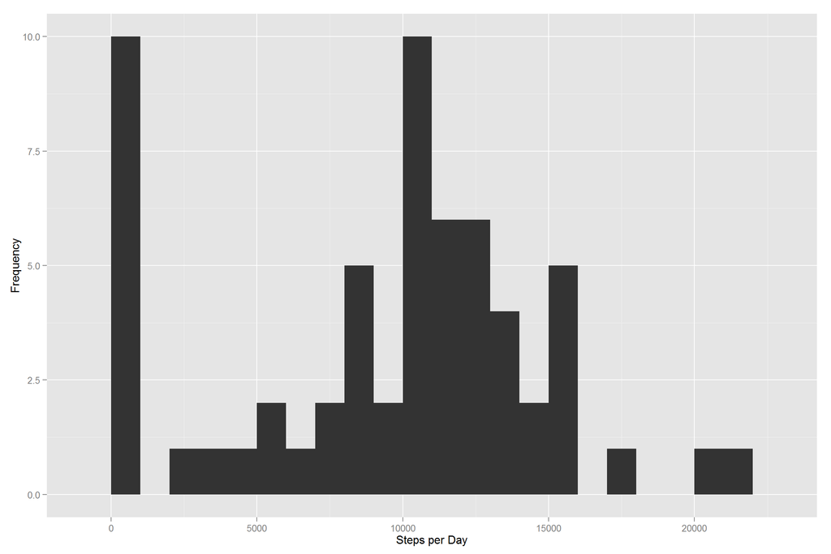

## What is the average daily activity pattern?

Calculate the mean steps for each five minute interval, and then put it in a data frame.

Plot the average number of steps for each TIME interval across all days

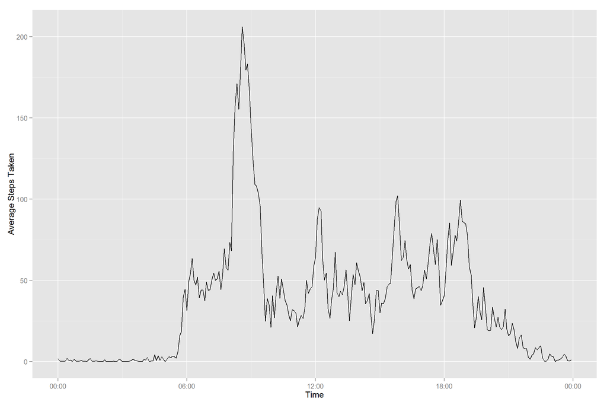

Use the which.max function to determine the interval during which the most steps are taken on average

```
## [1] "08:35"
```

## Imputing missing values

Count the missing values (“NA”s)

```
## TRUE
## 2304
```

Replace NAs with average steps for a 5-minute interval

Let’s compare the mean and median steps for each day between the original data set and the imputed data set.

```
## [1] 9354.23
```

```
## [1] 10766.19
```

```
## [1] 10395
```

```
## [1] 10766.19
```

Note the mean and median are now equal and greater than they were before values were imputed

Redraw teh histogram wth the imputed values

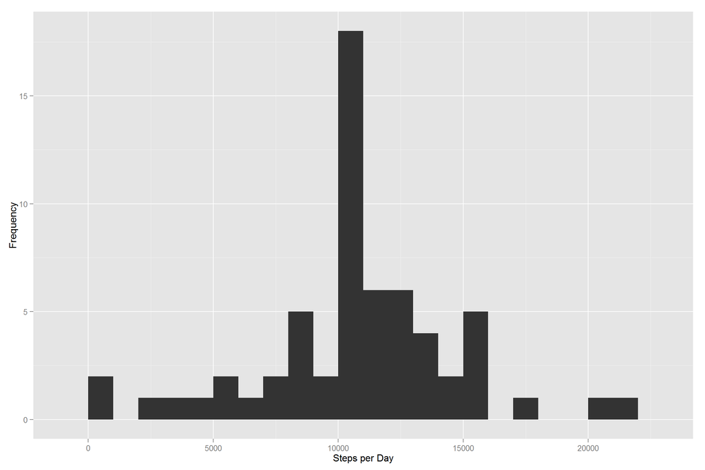

## Are there differences in activity patterns between weekdays and weekends?

Create a column describing dates as either weekdays or weekends

determine average steps for weekdays and weekends, and place each in a dataframe.

Plot the data for weekends and weekdays on adjacent graphs

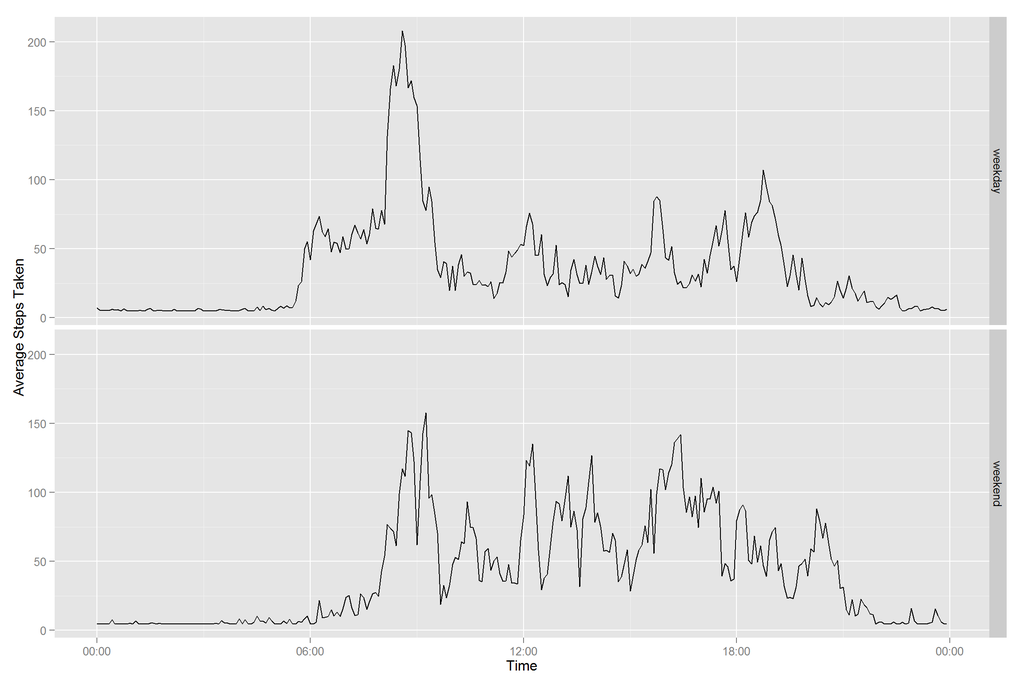